# Pie charts using matplotlib

# Percentage labels distance to the origin

Note that you can customize the distance of these labels from the origin and display them instead of the group labels. The default value is 0.6.

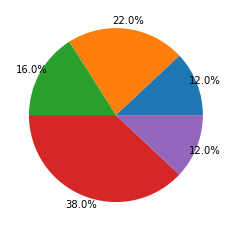

```python
# Data
labels = ["G1", "G2", "G3", "G4", "G5"]
value = [12, 22, 16, 38, 12]

# Pie chart
fig, ax = plt.subplots()
ax.pie(value, autopct = '%1.1f%%', pctdistance = 1.1)
plt.show()
```

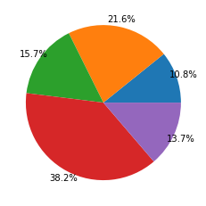

```python
labels = ["A1", "A2", "A3", "A4", "A5"]
value = [110, 220, 160, 390, 140]

# Pie chart
fig, ax = plt.subplots()
ax.pie(value, autopct = '%1.1f%%', pctdistance = 1.1)
plt.show()
```

# Group labels distance to the origin

In addition, you can also modify the default distance (1.1 for a slice of radius 1) of the group labels with labeldistance.

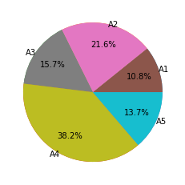

```python
labels = ["A1", "A2", "A3", "A4", "A5"]
value = [110, 220, 160, 390, 140]

# Pie chart
fig, ax = plt.subplots()
ax.pie(value, autopct = '%1.1f%%', pctdistance = 0.7)
ax.pie(value, labels = labels, labeldistance = 1.0)
plt.show()
```

# Labels rotation

Finally, it is also possible to rotate the group labels to the angle of the corresponding slice setting rotatelabels as True.

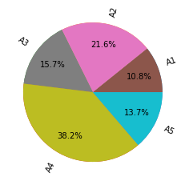

```python
labels = ["A1", "A2", "A3", "A4", "A5"]
value = [110, 220, 160, 390, 140]

# Pie chart
fig, ax = plt.subplots()
ax.pie(value, autopct = '%1.1f%%', pctdistance = 0.7)
ax.pie(value, labels = labels, labeldistance = 1.1, rotatelabels = True)
plt.show()
```

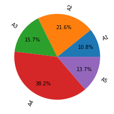

```python
labels = ["A1", "A2", "A3", "A4", "A5"]
value = [110, 220, 160, 390, 140]
# Pie chart
fig, ax = plt.subplots()
ax.pie(value, autopct = '%1.1f%%', pctdistance = 0.7, labels = labels, labeldistance = 1.1, rotatelabels = True)
plt.show()
```

# Pie chart colors

The colors argument allows customizing the fill color for each slice. You can input an array of ordered colors to change the color for each category.

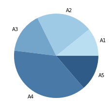

```python
labels = ["A1", "A2", "A3", "A4", "A5"]
value = [110, 220, 160, 390, 140]
colors = ["#B9DDF1", "#9FCAE6", "#73A4CA", "#497AA7", "#2E5B88"]

# Pie chart
fig, ax = plt.subplots()
ax.pie(value, labels = labels, colors = colors)
plt.show()
```

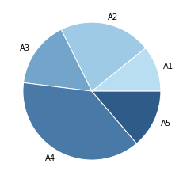

```python
labels = ["A1", "A2", "A3", "A4", "A5"]
value = [110, 220, 160, 390, 140]
colors = ["#B9DDF1", "#9FCAE6", "#73A4CA", "#497AA7", "#2E5B88"]

# Pie chart
fig, ax = plt.subplots()
ax.pie(value, labels = labels, colors = colors,
      wedgeprops = {"linewidth": 1, "edgecolor": "white"})
plt.show()
```

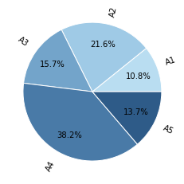

```python
labels = ["A1", "A2", "A3", "A4", "A5"]
value = [110, 220, 160, 390, 140]
colors = ["#B9DDF1", "#9FCAE6", "#73A4CA", "#497AA7", "#2E5B88"]

# Pie chart
fig, ax = plt.subplots()
ax.pie(value,  autopct = '%1.1f%%', pctdistance = 0.7,
       labels = labels, colors = colors, labeldistance = 1.1, rotatelabels = True,
      wedgeprops = {"linewidth": 1, "edgecolor": "white"})
plt.show()
```

# References:

```
# 1. https://python-charts.com/part-whole/pie-chart-matplotlib/
# 2. https://matplotlib.org/
```